# #TidyTuesday 2023-09-26: Roy Kent F**k count

Published

2025-06-02

# Background

For Deepsha Menghani’s talk on [Data Viz animation and interactivity in Quarto](https://deepshamenghani.github.io/posit_plotly_crosstalk/#/title-slide), she watched each episode of Ted Lasso at 2X speed and diligently noted down every F*bomb and gesture reference, and then made it into the [richmondway R package](https://github.com/deepshamenghani/richmondway)!

What is Ted Lasso and who is Roy Kent?

[Ted Lasso](https://en.wikipedia.org/wiki/Ted_Lasso) is a TV show that “follows Ted Lasso, an American college football coach who is hired to coach an English soccer team with the secret intention that his inexperience will lead it to failure, but whose folksy, optimistic leadership proves unexpectedly successful.”

[Roy Kent](https://ted-lasso.fandom.com/wiki/Roy_Kent) is one of the main characters who goes from captain of AFC Richmond to one of the coaches. Particularly in early seasons, he’s a man of few words, but many of them are f**k, expressed in various moods - mad, sad, happy, amused, loving, surprised, thoughtful, and joyous.

This dataset includes the number, percentage, and context of f**k used in the show for each episode.

# Load the weekly data and check the [readme](https://github.com/rfordatascience/tidytuesday/tree/main/data/2023/2023-09-26)

# Season changes

In the third season Roy Kent gave 105% more f*cks than in the first season, and other characters gave 112% more.

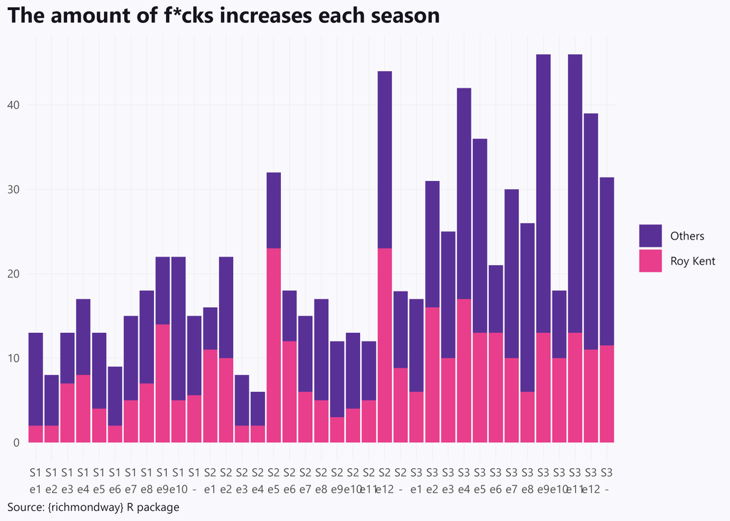

Figure 1: F*cks per episode over seasons

Statistics on the total number of f*cks per season

| Statistic | Season 1 | Season 2 | Season 3 | Total |
| --- | --- | --- | --- | --- |
| Minimum | 8.0 | 6.0 | 17.0 | 6.0 |
| P25 | 13.0 | 12.0 | 24.0 | 13.0 |
| Median | 14.0 | 15.5 | 30.5 | 18.0 |
| P75 | 17.8 | 19.0 | 39.8 | 29.0 |
| Maximum | 22.0 | 44.0 | 46.0 | 46.0 |
| Mean | 15.0 | 17.9 | 31.4 | 21.8 |
| LCI | 5.6 | -2.9 | 11.1 | -0.8 |
| UCI | 24.4 | 38.8 | 51.8 | 44.4 |

{richmondway} R package

Table 1: Statistics on the total number of f*cks per season

# IMDB

There is no correlation between the number of f*cks and the IMDB rating overall, and only a weak relationship within each season.

Pearson's correlation of number of f*cks and IMDB rating

| Season | Correlation | P-value | Strength |
| --- | --- | --- | --- |
| Season 1 | 46.3% | 0.18 | Weak relationship |
| Season 2 | 35.6% | 0.26 | Weak relationship |
| Season 3 | 31.4% | 0.32 | Weak relationship |
| Total | 17.0% | 0.34 | No relationship |

{richmondway} R package

Table 2: Pearson’s correlation of number of f*cks and IMDB rating.

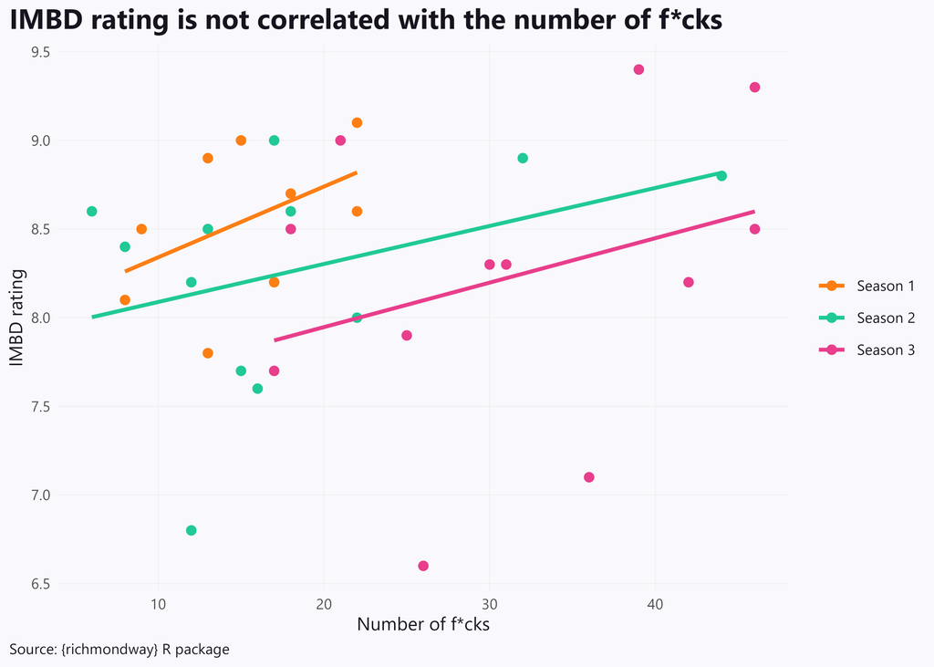

Figure 2: F*cks vs IMDB rating

The IMDB ratings drop each season.

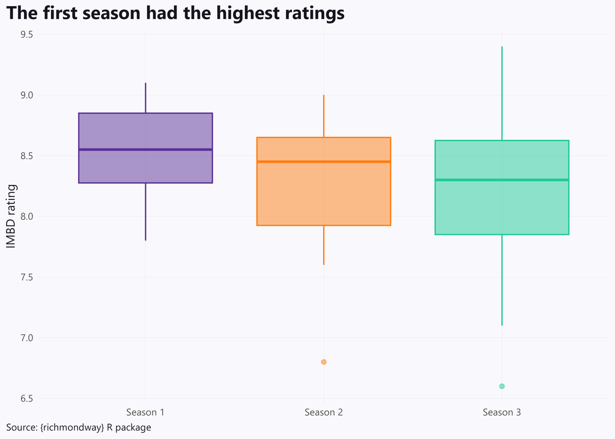

Figure 3: Boxplot of IMDB ratings by season